# Oklahoma City 103-91 Indiana

Oklahoma City 103 - 91 Indiana · NBA · 2025-06-22

## Key findings

- **Oklahoma City beat Indiana by 12** (103-91). There were 11 lead changes and 10 ties; the biggest leads were 22 for Oklahoma City and 5 for Indiana.
- **What decided it: turnovers.** It was worth about +21.5 points to Oklahoma City (23 turnovers against 8) even though Indiana shot better (49% against 47% effective FG%).
- **The biggest swing:** Cason Wallace makes 22-foot three point jumper (73-66, period 3), which moved Oklahoma City’s chances by 10 points.
- **Who mattered most:** Shai Gilgeous-Alexander for Oklahoma City (29 points, +33 points of win probability); T.J. McConnell for Indiana (16 points, +19).
- **Best run:** 13-0 Oklahoma City.
- **Shots:** Oklahoma City 24/47 twos, 11/40 threes; Indiana 18/42 twos, 11/28 threes.
- The game never reached clutch time (last 5 minutes within 5 points).

## How the game unfolded

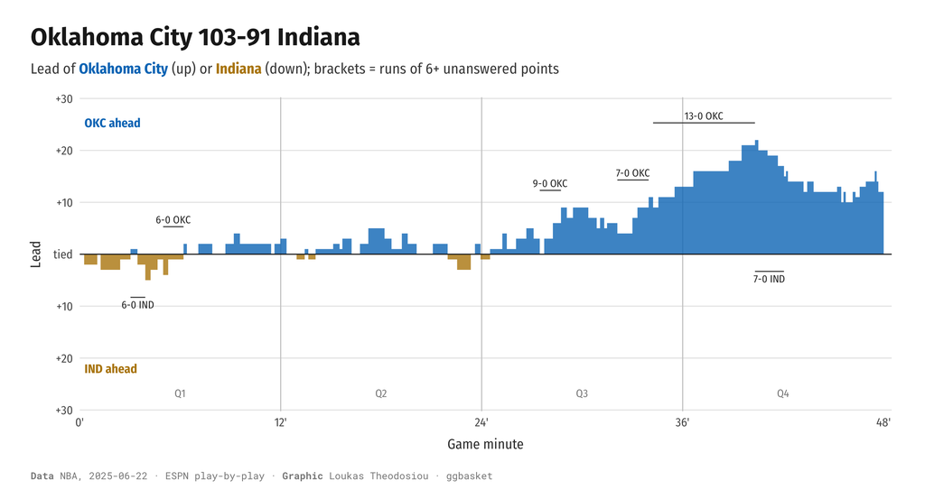

## The plays that decided it

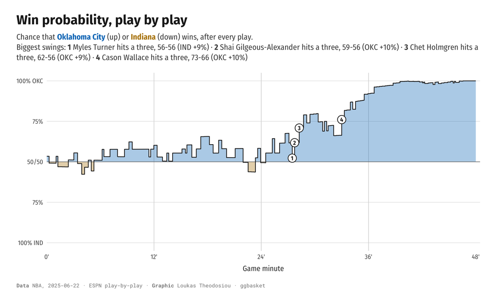

## Why the result went the way it did

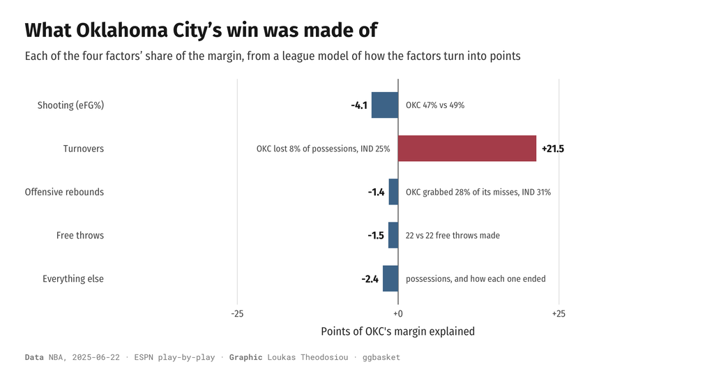

## Who mattered

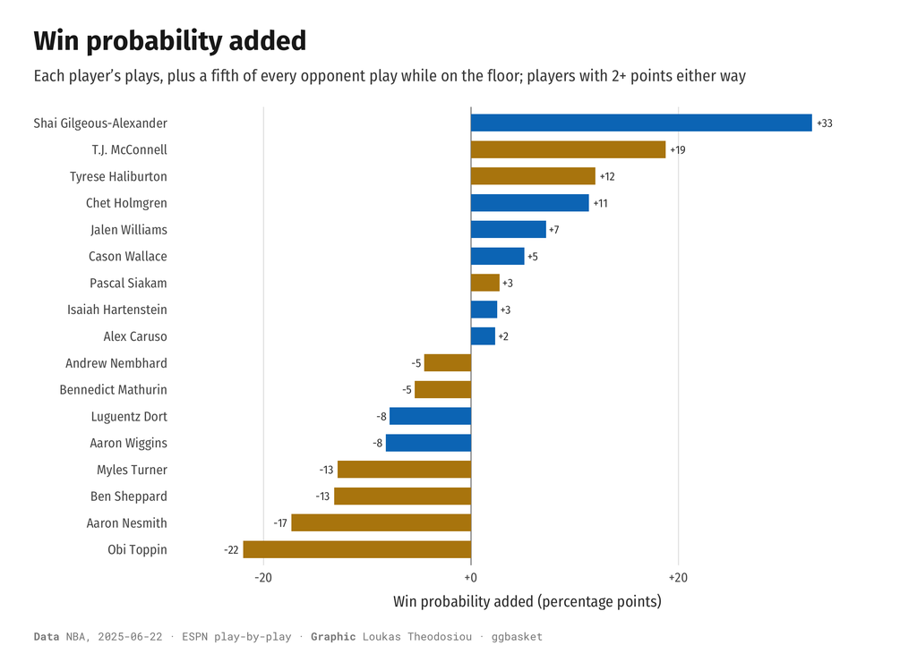

## Where the shots came from

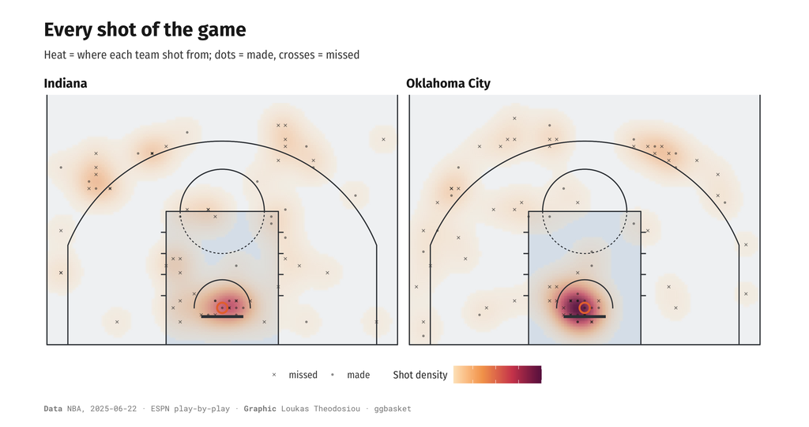

## Box scores

**Oklahoma City**

| Player | MIN | PTS | 2P | 3P | FT | REB | AST | STL | BLK | TOV | +/- | GmSc |
| --- | --- | --- | --- | --- | --- | --- | --- | --- | --- | --- | --- | --- |
| Shai Gilgeous-Alexander | 40 | 29 | 6/15 | 2/12 | 11/12 | 5 | 12 | 1 | 2 | 1 | 10 | 22.2 |
| Jalen Williams | 38 | 20 | 5/13 | 2/7 | 4/6 | 4 | 4 | 2 | 0 | 1 | 11 | 11.4 |
| Luguentz Dort | 35 | 9 | 1/1 | 2/9 | 1/2 | 7 | 0 | 3 | 0 | 1 | 10 | 6.9 |
| Alex Caruso | 32 | 10 | 2/5 | 2/5 | 0/0 | 3 | 0 | 3 | 1 | 0 | 5 | 8.8 |
| Chet Holmgren | 31 | 18 | 5/6 | 1/2 | 5/8 | 8 | 0 | 1 | 5 | 0 | 10 | 20.1 |
| Cason Wallace | 26 | 10 | 2/3 | 2/3 | 0/0 | 2 | 0 | 3 | 0 | 1 | 11 | 9.6 |
| Isaiah Hartenstein | 18 | 7 | 3/4 | 0/0 | 1/3 | 9 | 4 | 1 | 0 | 2 | 0 | 10.3 |
| Aaron Wiggins | 12 | 0 | 0/0 | 0/1 | 0/0 | 1 | 0 | 0 | 0 | 0 | 12 | -0.8 |
| Kenrich Williams | 5 | 0 | 0/0 | 0/1 | 0/0 | 1 | 0 | 0 | 0 | 0 | 0 | 0.0 |
| Ajay Mitchell | 1 | 0 | 0/0 | 0/0 | 0/0 | 0 | 0 | 0 | 0 | 1 | -3 | -1.0 |
| Dillon Jones | 1 | 0 | 0/0 | 0/0 | 0/0 | 0 | 0 | 0 | 0 | 0 | -3 | -0.4 |
| Ousmane Dieng | 1 | 0 | 0/0 | 0/0 | 0/0 | 0 | 0 | 0 | 0 | 0 | -3 | 0.0 |

**Indiana**

| Player | MIN | PTS | 2P | 3P | FT | REB | AST | STL | BLK | TOV | +/- | GmSc |
| --- | --- | --- | --- | --- | --- | --- | --- | --- | --- | --- | --- | --- |
| Pascal Siakam | 37 | 16 | 3/8 | 2/5 | 4/7 | 4 | 2 | 1 | 1 | 1 | -2 | 10.6 |
| Andrew Nembhard | 37 | 15 | 2/7 | 2/3 | 5/6 | 5 | 6 | 0 | 0 | 2 | -9 | 12.1 |
| Bennedict Mathurin | 33 | 24 | 4/9 | 2/5 | 10/10 | 13 | 3 | 2 | 0 | 3 | -15 | 23.2 |
| Aaron Nesmith | 30 | 3 | 0/2 | 1/3 | 0/0 | 6 | 1 | 2 | 2 | 1 | 5 | 2.8 |
| T.J. McConnell | 28 | 16 | 8/13 | 0/0 | 0/0 | 6 | 3 | 1 | 1 | 7 | -7 | 7.9 |
| Myles Turner | 24 | 6 | 1/1 | 1/3 | 1/4 | 4 | 1 | 0 | 0 | 1 | -13 | 2.9 |
| Obi Toppin | 21 | 0 | 0/1 | 0/3 | 0/0 | 2 | 1 | 0 | 0 | 3 | -16 | -5.3 |
| Ben Sheppard | 16 | 0 | 0/0 | 0/1 | 0/0 | 4 | 0 | 0 | 0 | 1 | -3 | -0.5 |
| Tyrese Haliburton | 7 | 9 | 0/1 | 3/4 | 0/0 | 0 | 0 | 0 | 0 | 1 | -2 | 5.7 |
| Tony Bradley | 5 | 2 | 0/0 | 0/0 | 2/2 | 1 | 0 | 0 | 0 | 1 | -2 | 0.5 |
| Thomas Bryant | 1 | 0 | 0/0 | 0/1 | 0/0 | 0 | 0 | 0 | 0 | 0 | 1 | -0.7 |
| Johnny Furphy | 1 | 0 | 0/0 | 0/0 | 0/0 | 0 | 0 | 0 | 0 | 0 | 3 | 0.0 |

## Clutch time and line-ups

The game never reached clutch time (last 5 minutes within 5 points).

Five-player units with 4+ minutes together:

| Team | Line-up | MIN | Pts for | Pts against |
| --- | --- | --- | --- | --- |
| Oklahoma City | Alex Caruso, Chet Holmgren, Jalen Williams, Luguentz Dort, Shai Gilgeous-Alexander | 9.9 | 24 | 20 |
| Indiana | Aaron Nesmith, Andrew Nembhard, Bennedict Mathurin, Pascal Siakam, T.J. McConnell | 6.3 | 10 | 10 |
| Oklahoma City | Cason Wallace, Chet Holmgren, Jalen Williams, Luguentz Dort, Shai Gilgeous-Alexander | 6.1 | 19 | 8 |
| Oklahoma City | Aaron Wiggins, Alex Caruso, Cason Wallace, Isaiah Hartenstein, Jalen Williams | 5.9 | 13 | 8 |
| Indiana | Ben Sheppard, Bennedict Mathurin, Obi Toppin, Pascal Siakam, T.J. McConnell | 4.9 | 6 | 6 |
| Indiana | Aaron Nesmith, Andrew Nembhard, Myles Turner, Pascal Siakam, Tyrese Haliburton | 4.7 | 11 | 9 |
| Oklahoma City | Chet Holmgren, Isaiah Hartenstein, Jalen Williams, Luguentz Dort, Shai Gilgeous-Alexander | 4.7 | 9 | 11 |
| Oklahoma City | Alex Caruso, Isaiah Hartenstein, Jalen Williams, Luguentz Dort, Shai Gilgeous-Alexander | 4.0 | 10 | 11 |
| Indiana | Aaron Nesmith, Andrew Nembhard, Bennedict Mathurin, Myles Turner, Pascal Siakam | 4.0 | 4 | 11 |